# Agencias de Viajes y de Turismo Estudiantil

Caracterización del sector en base al Registro de Agencias de Viajes de la Dirección Nacional de Agencias de Viajes (datos a marzo de 2022)

Según los datos del Registro de Agencias de Viajes de la Dirección Nacional de Agencias de Viajes al 15 de marzo de 2022 había registradas 5.150 en todo el país. En base a la información declarada por estas agencias se caracteriza el sector en relación a su distribución geográfica y el tipo de turismo con el que operan.

# TIPO DE TURISMO

Las agencias de viajes y turismo pueden operar con turismo interno, turismo internacional, o ambas. De las 5150 agencias el 88,54%, es decir 4.560 agencias, opera con turismo internacional, ya sea receptivo y/o emisivo. Mientras que 3.035 agencias declararon operar con turismo interno, representando un 58,9% del universo considerado.

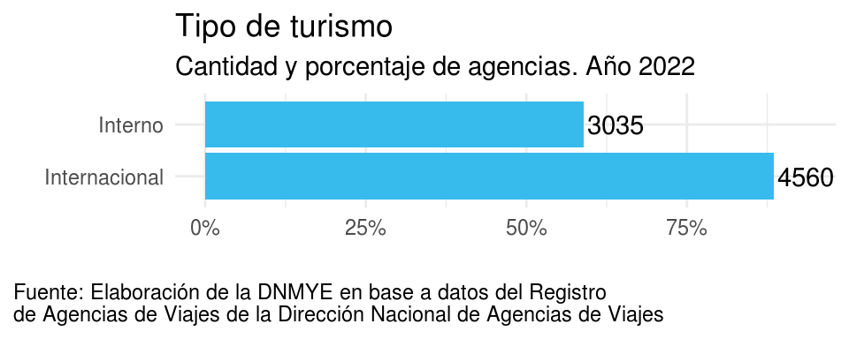

Al analizar el tipo de turismo internacional, se puede ver que un 69,5% declara comercializar solo turismo emisivo, mientras que un 18,3% realiza tanto operaciones de turismo receptivo como de turismo emisivo, y un 12,2% opera turismo receptivo exclusivamente.

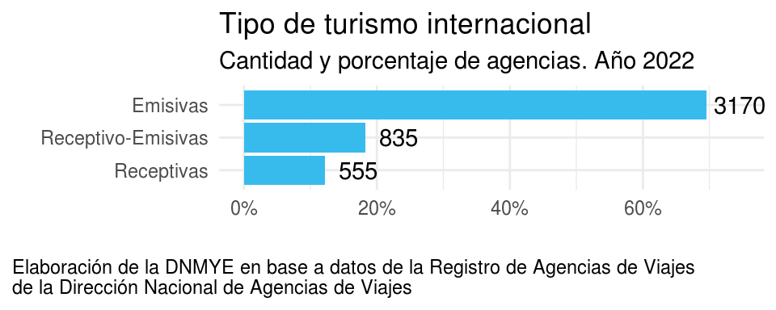

Si bien en el agregado nacional hay un predominio de la actividad en torno al turismo emisivo, existen diferencias a nivel subnacional, tanto en relación a la cantidad de agencias como a su distribución según el tipo de turismo con el que operan.

# GEOGRAFÍA DEL SECTOR

De las 5.150 agencias que se registran en el país, la mayor parte se concentra en la Ciudad Autónoma de Buenos Aires y en la provincia de Buenos Aires. En tercer y cuarto lugar según la cantidad de agencias registradas se ubican las provincias de Córdoba y Santa Fe. En conjunto estas cuatro provincias explican el 66,95% del total del país.

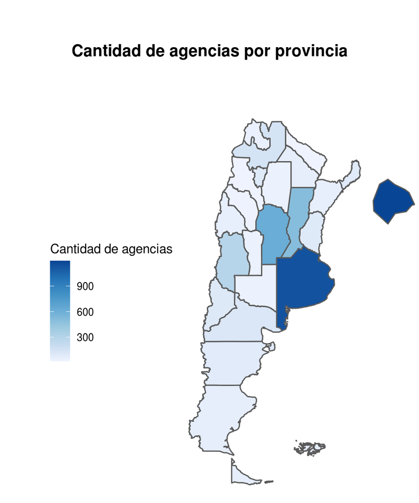

Además de la concentración territorial descripta, se observa un comportamiento heterogéneo en cuanto al tipo de turismo operado por las agencias según provincia. El mapa a continuación representa la cantidad de agencias de viaje por provincia y la proporción de las mismas que realiza servicios de turismo interno.

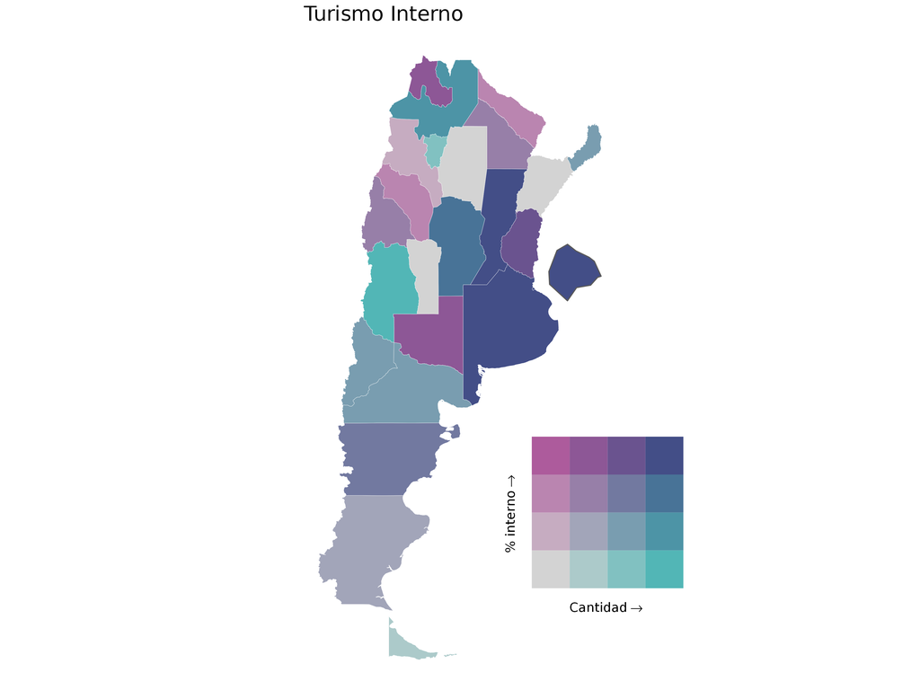

Se puede apreciar que la proporción de agencias que realiza turismo interno no se distribuye de forma análoga a la cantidad de agencias a lo largo de país. En el grupo de provincias con mayor peso de servicios de turismo interno, además de aparecer Ciudad Autónoma de Buenos Aires, Buenos Aires y Santa Fe, que suman 2.835 agencias, también se encuentran las provincias de Jujuy, La Pampa y Entre Ríos, provincias con menos de 100 agencias cada una. Por otra parte, provincias con una elevada cantidad de agencias como Mendoza y Salta se hallan entre las que tienen una menor proporción de agencias que realizan operaciones de turismo interno.

Si reproducimos el análisis anterior para los diferentes tipos de operaciones con turismo internacional podemos distinguir el peso del turismo receptivo y el turismo emisivo en el sector de agencias de viaje para cada provincia.

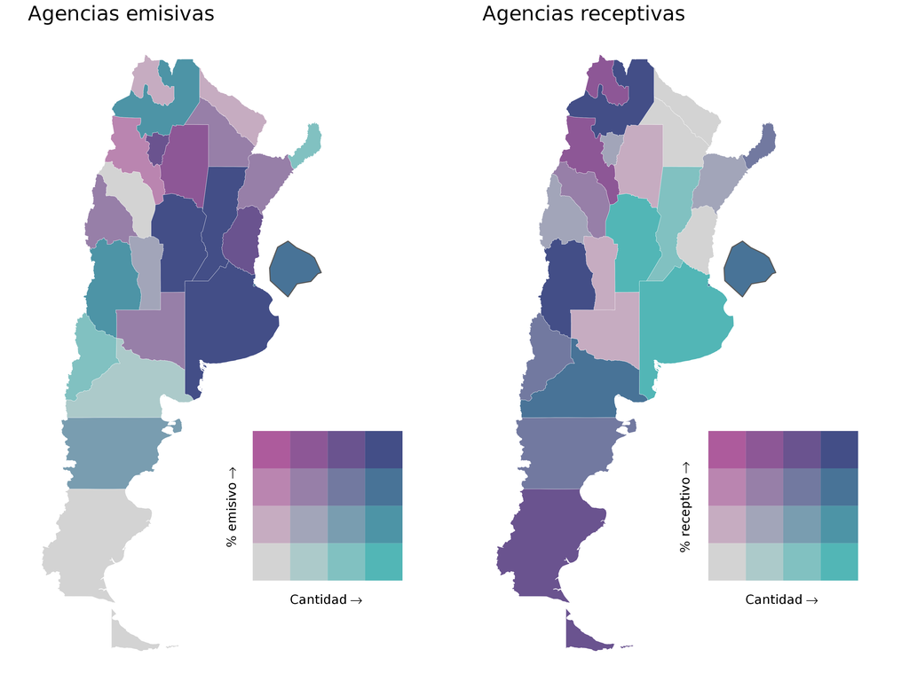

Así, por una parte se puede ver que las cinco provincias con mayor peso del turismo emisivo representan 2.378 agencias, con Buenos Aires, Santa Fe y Córdoba en el top tres según proporción del turismo emisivo. Mientras que por otra parte las cinco provincias con mayor peso del turismo receptivo suman 572 agencias, con Salta, Catamarca y Tierra del Fuego entre las tres primeras.

# MERCADOS

Para un subconjunto de las agencias que realiza turismo receptivo (656 agencias) se puede analizar con qué mercados declararon trabajar. Para esta muestra de agencias la región con mayor participación es Europa, con la cual opera el 65,4% de las agencias de la muestra, en segundo lugar le sigue Brasil operada por el 63,6% de las mismas. Por su lado, China es el mercado que cuenta con menor presencia, un 29,7% de las agencias declaró operar con él.

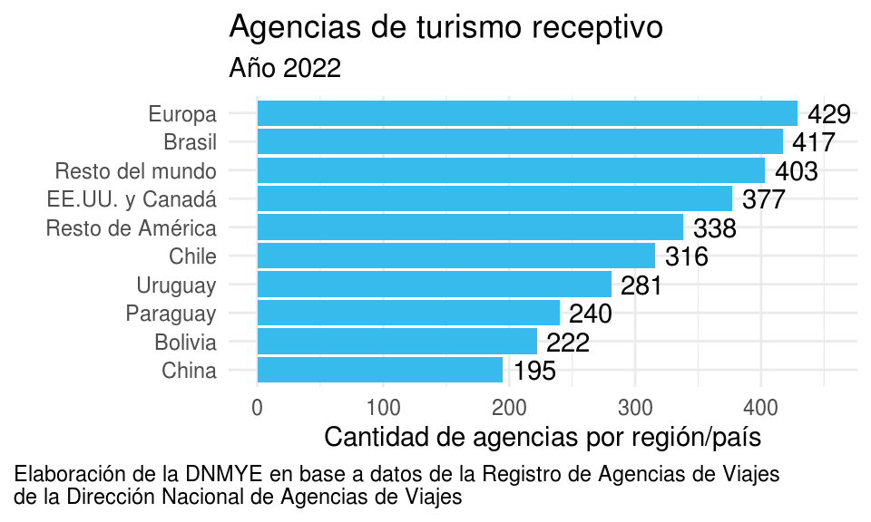

Al analizar la distribución de agencias por cantidad de mercados que operan, se destaca que en mayor medida trabajan con una única región o con todas.

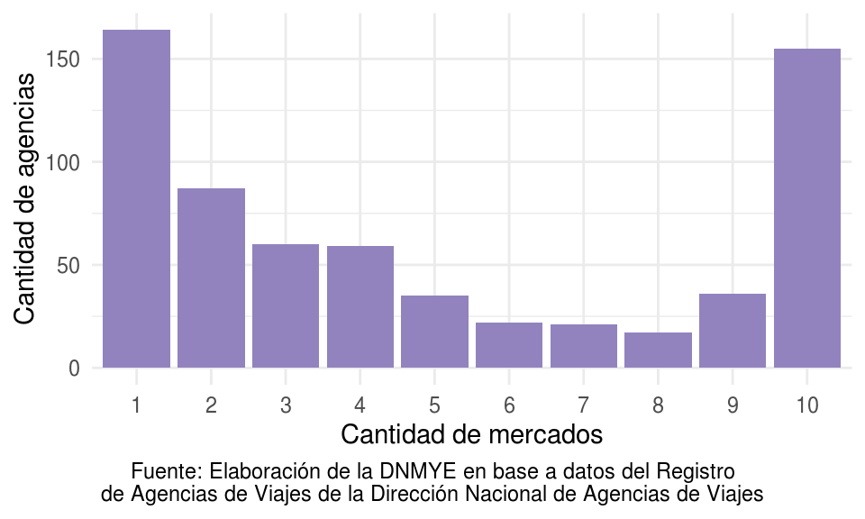

Poniendo foco en el grupo de agencias que opera un solo mercado se encuentra que el 50,6% indicó “Resto del mundo” como única región.

## TURISMO ESTUDIANTIL

Uno de los segmentos especializados es el de turismo estudiantil, el cual contabilizaba al 15 de marzo de 2022 un total de 225 agencias (4,4% del total de agencias habilitadas). En relación al tipo de viaje ofrecido, un 79,6% organiza o comercializa viajes de estudios, mientras que un 65,8% distribuye viajes de egresados.

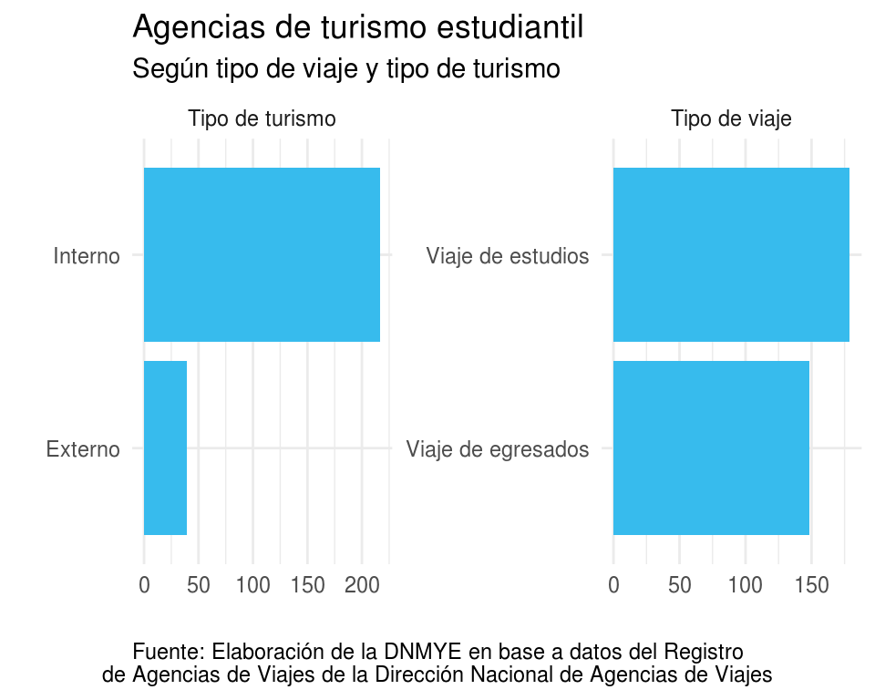

Respecto del destino, un 96,4% realiza viajes en el país y un 17,3% en el exterior. El principal destino nacional seleccionado por el segmento estudiantil es Carlos Paz, al cual viajan el 60% de las agencias, seguido de Bariloche (35,6%).

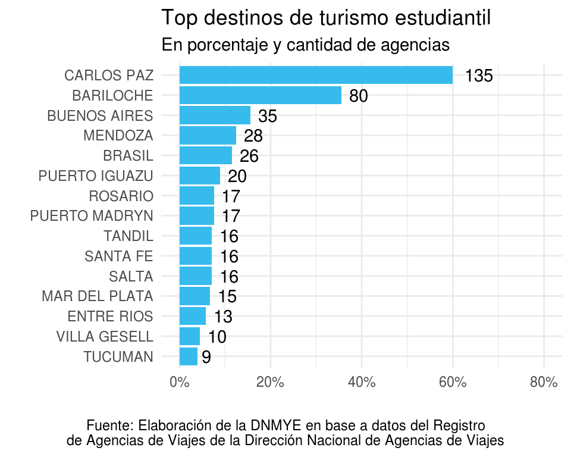

# TABLERO INTERACTIVO DE AGENCIAS

A partir de los datos del Registro de Agencias de Viajes de la Dirección Nacional de Agencias de Viajes la Dirección Nacional de Mercados y Estadísticas hace público para la consulta de los datos aquí presentados el [Tablero de Agencias de Viaje](https://tableros.yvera.tur.ar/agencias/).

[figure not shown]